# Homework 5

Jonathan Bruner

2024-03-17

# Question 1

The file *FEV.csv* on D2L contains information related to forced expiratory volume (FEV) tests evaluating pulmonary capacity.

### (a) Create and interpret a plot of height versus FEV treating FEV as the dependent variable

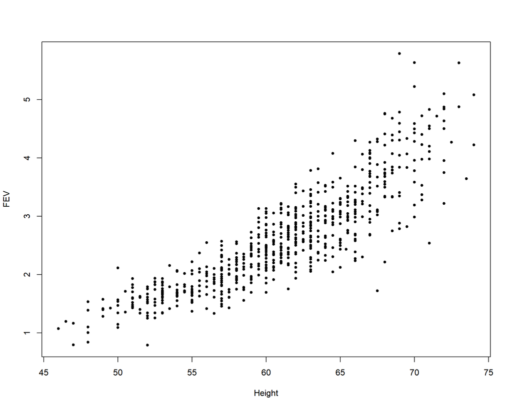

```r
dat1 = read.csv('FEV.csv')

plot(dat1$height, dat1$fev, xlab='Height', ylab='FEV', pch=20)
```

### (b) Fit a natural cubic spline to predict FEV using height. Select the degrees of freedom using LOOCV choosing between values of 5, 6, 7, and 8. What value is chosen?

```r
# Alternate Code
cv.error = NA
for (i in 1:4){
  fit = glm(fev ~ ns(height, df=list[i]), data=dat1)
  cv.error[i] = cv.glm(dat1, fit)$delta[1]
}
```

```r
list = c(5,6,7,8)
model = data.frame('df'=list)
error = NA

for (i in 1:4){
  for (j in 1:nrow(dat1)){
    fit = glm(fev ~ ns(height, df=list[i]), data=dat1[-j,])
    pred = predict(fit, dat1[j,])
    error[j] = (pred - dat1$fev[j])^2
  }
  model[i,'MSE'] = mean(error)
}

ns_fit = glm(fev ~ ns(height, df=model$df[which.min(model$MSE)]), data=dat1)
ns_pred = predict(ns_fit)
ns_dat = data.frame(height = dat1$height, ns_pred)
ns_dat = ns_dat[order(ns_dat$height),]

model
```

```
##   df       MSE
## 1  5 0.1721838
## 2  6 0.1695393
## 3  7 0.1694243
## 4  8 0.1696765
```

Based of the LOOCV used above, we would choose 7 degrees of freedom for this natural cubic spline.

### (c) Fit a smoothing spline to predict FEV using height. Use LOOCV to choose the value of the smoothing parameter. Note: you will probably get a warning here - you can ignore this warning.

```r
smooth_fit = smooth.spline(dat1$height, dat1$fev, cv=TRUE)
smooth_pred = predict(smooth_fit)
```

### (d) Fit a local regression using span of 0.8 to predict FEV using height.

```r
loreg_fit = loess(fev ~ height, data=dat1, span=0.8)
loreg_pred = predict(loreg_fit)
loreg_dat = data.frame(height=dat1$height, loreg_pred)
loreg_dat <- loreg_dat[order(loreg_dat$height), ]
```

### (e) Add the resulting fits from parts (b) - (d) to your plot from part (a). You only need to plot the best model from part (b).

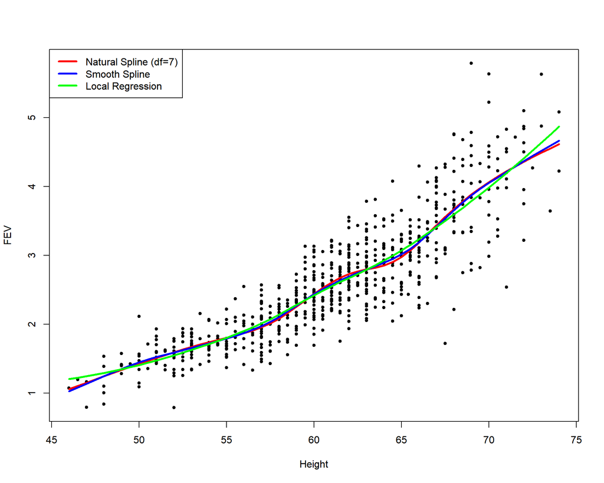

```r
plot(dat1$height, dat1$fev, xlab='Height', ylab='FEV', pch=20)

# Add Natural Spline with 7 degrees of freedom
lines(ns_dat$height, ns_dat$ns_pred, type = "l", col = "red", lwd = 3)

# Add Smooth Spline
lines(smooth_pred$x, smooth_pred$y, type = "l", col = "blue", lwd = 3)

# Add Local Regression with span of 0.8
lines(loreg_dat$height, loreg_dat$loreg_pred, type = "l", col = "green", lwd = 3)

legend('topleft',
       legend=c('Natural Spline (df=7)','Smooth Spline','Local Regression'),
       col=c('red','blue','green'),
       lwd = 3)
```

### (f) Create a training and test set and repeat parts (b) - (d) on the training data. Which model produces the lowest test MSE?

```r
set.seed(1)
train = sample(1:nrow(dat1), 0.8*nrow(dat1))
train_dat1 = dat1[train,]
test_dat1 = dat1[-train,]

# Natural Spline
list = c(5,6,7,8)
model = data.frame('df'=list)
error = NA

for (i in 1:4){
  for (j in 1:nrow(train_dat1)){
    fit = glm(fev ~ ns(height, df=list[i]), data=train_dat1[-j,])
    pred = predict(fit, train_dat1[j,])
    error[j] = (pred - train_dat1$fev[j])^2
  }
  model[i,'MSE'] = mean(error)
}

ns_fit = glm(fev ~ ns(height, df=model$df[which.min(model$MSE)]), data=train_dat1)
ns_pred = predict(ns_fit, test_dat1)
Models = data.frame(
  Models = c(paste('Natural Spline (df=',model$df[which.min(model$MSE)],')',sep=''),
           'Smooth Spline',
           'Local Regression'
           )
  )
Models[1,'Test Error'] = mean((test_dat1$fev - ns_pred)^2)

# Smooth Spline
smooth_fit = smooth.spline(train_dat1$height, train_dat1$fev, cv=TRUE)
smooth_pred = predict(smooth_fit, test_dat1$height)
Models[2,'Test Error'] = mean((test_dat1$fev - smooth_pred$y)^2)

# Local Regression on span of 0.8
loreg_fit = loess(fev ~ height, data=train_dat1, span=0.8)
loreg_pred = predict(loreg_fit, test_dat1)
Models[3,'Test Error'] = mean((test_dat1$fev - loreg_pred)^2)

Models
```

```
##                  Models Test Error
## 1 Natural Spline (df=7)  0.1848532
## 2         Smooth Spline  0.1817948
## 3      Local Regression  0.1760447
```

Out of these 3 models, Local Regression had the lowest MSE.

# Question 2: Chapter 7 Exercise 9 parts (d)-(f) only

This question uses the variables **dis** (the weighted mean of distances to five Boston employment centers) and **nox** (nitrogen oxides concentration in parts per 10 million) from the *Boston* data. We will treat **dis** as the predictor and **nox** as the response.

### (d) Use the *bs()* function to fit a regression spline to predict **nox** using **dis**. Report the output for the fit using four degrees of freedom. How did you choose the knots? Plot the resulting fit.

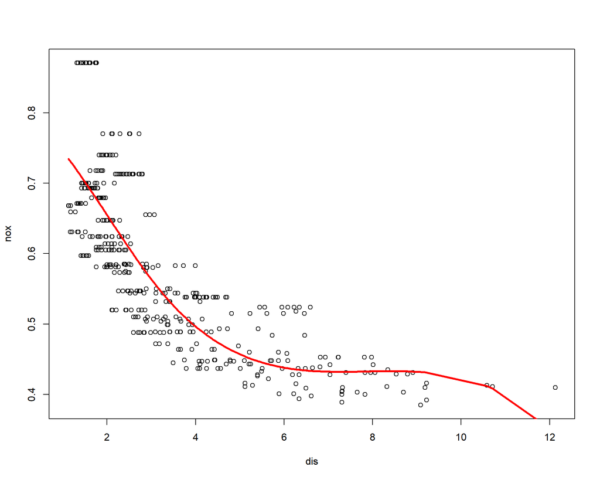

```r
dat2 = Boston

fit2 = glm(nox ~ bs(dis, df=4), data=dat2)
pred2=predict(fit2)

pred_dat = data.frame(dis=dat2$dis, pred2)
pred_dat = pred_dat[order(pred_dat$dis),]

plot(dat2$dis, dat2$nox, xlab='dis', ylab='nox')
lines(pred_dat$dis, pred_dat$pred2, type='l', col='red', lwd=3)
```

I did not choose the knots. Using the 4 degrees of freedom, r chose the following knots: 3.20745. This doesn’t include the boundary knots that are defined as the range of the non-NA data.

### (e) Now fit the regression spline for a range of degrees of freedom, and plot the resulting fits and report the resulting RSS. Describe the results obtained.

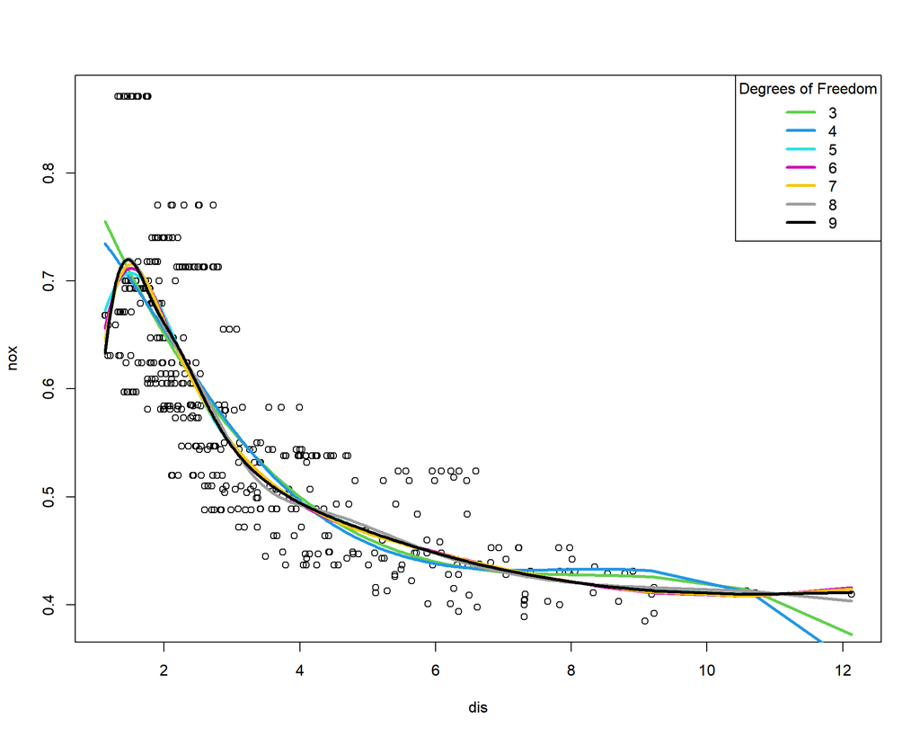

```r
plot(dat2$dis, dat2$nox, xlab='dis', ylab='nox')
model = data.frame(df=c(3:9))

for (i in 3:9){
  fit = glm(nox ~ bs(dis, df=i), data=dat2)
  pred = predict(fit)

  plot_dat = data.frame(dis=dat2$dis, pred)
  plot_dat = plot_dat[order(plot_dat$dis),]

  lines(plot_dat$dis, plot_dat$pred, type='l', col=i, lwd=3)

  model[i-2,'RSS'] = sum((pred - dat2$nox)^2)
}

legend('topright',
       legend=c(3:9),
       col=c(3:9),
       lwd=3,
       title='Degrees of Freedom')
```

```r
model
```

```
##   df      RSS
## 1  3 1.934107
## 2  4 1.922775
## 3  5 1.840173
## 4  6 1.833966
## 5  7 1.829884
## 6  8 1.816995
## 7  9 1.825653
```

### (f) Perform cross-validation or another approach in order to select the best degrees of freedom for a regression spline in this data. Describe your results.

```r
model = data.frame(df=c(3:20))
error = NA

for (i in 3:20){
  for (j in 1:nrow(dat2)){
    fit = glm(nox ~ bs(dis, df=i), data=dat2[-j,])
    pred = predict(fit, dat2[j,])

    error[j] = (pred - dat2$nox[j])^2
  }

  model[i-2,'MSE'] = mean(error)
}

model
```

```
##    df         MSE
## 1   3 0.003874762
## 2   4 0.003893623
## 3   5 0.003704252
## 4   6 0.003704711
## 5   7 0.003711441
## 6   8 0.003699853
## 7   9 0.003731180
## 8  10 0.003692067
## 9  11 0.003715438
## 10 12 0.003701170
## 11 13 0.003706427
## 12 14 0.003731061
## 13 15 0.003753817
## 14 16 0.003767285
## 15 17 0.003766139
## 16 18 0.003764804
## 17 19 0.003780036
## 18 20 0.003808748
```

```r
model[which.min(model$MSE),]
```

```
##   df         MSE
## 8 10 0.003692067
```

I’m not sure what the difference between this question and the previous question, but I extended the amount of numbers tested. I found the 10 degrees of freedom has the smallest MSE.

# Question 3: Chapter 7 Exercise 3

### Suppose we fit a curve with basis functions $b_1(X)=X, b_2(X)=(X-1)^2I(X\ge1)$. (Note that $I(X\ge1)$ equals 1 for $X\ge1$ and 0 otherwise.) We fit the linear regression model $$Y=\beta_0+\beta_1b_1(X)+\beta_2b_2(X)+\epsilon$$ , and obtain coefficient estimates $\hat{\beta_0}=1, \hat{\beta_1}=1, \hat{\beta_2}=-2$. Note the intercepts, slopes, and other relevant information

For both of the basis functions the intercept is at (0,0), but for $Y$ the intercept is at (-1,0). The slope of $b_1$ is 1, the slope of $b_2$ is 0 for $x<1$ and when $x\ge1$ it is a positive parabola. For $Y$ the slope is 1 for $x<1$, and when $x\ge1$ it is a negative parabola. The reason we go from a positive parabola in $b_2$ to a negative parabola in $Y$ is $\hat{\beta_2}=-2$.